# Midterm

McKenzie Kozma

11/11/2019

This chunk created a smaller version of the dataset so that computations will be easier; includes years of admission of 2016, 2017, and 2018.

```r
#RIdata <- read_sas("C:/Users/student/Documents/GitHub/hdd0318cy.sas7bdat", NULL)

#RIdata2 <- RIdata %>%
  #mutate_all(~na_if(., "")) %>%
  #remove_empty("cols") %>%
  #select(-contains("filler")) %>%
  #filter(yoa %in% c(16,17,18)) %>%
  #write_csv("Data.csv")
```

The data is also more thoroughly cleaned at this point. - Filtered for sex of 1 or 2 where 1 = male.

```r
library(tidyverse)
library(haven)
library(janitor)
```

```r
library(ggplot2)
library(caret)
library(rpart)
library(ada)

DATA <- read_csv("Data.csv")
DATA2 <- DATA %>%
  filter(sex %in% c(1,2),
         !is.na(race),
         race != 9,
         !is.na(as.numeric(payer))) %>%
  mutate(sex = factor(sex),
         race = factor(race)) %>%
  mutate_at(vars(c(32, 33, 37:50, 60, 62, 63, 65, 67)), ~as.numeric(.)) %>%
  select(-c(dx19:px25, poa19:poa23))
```

DATA VISUALIZATION

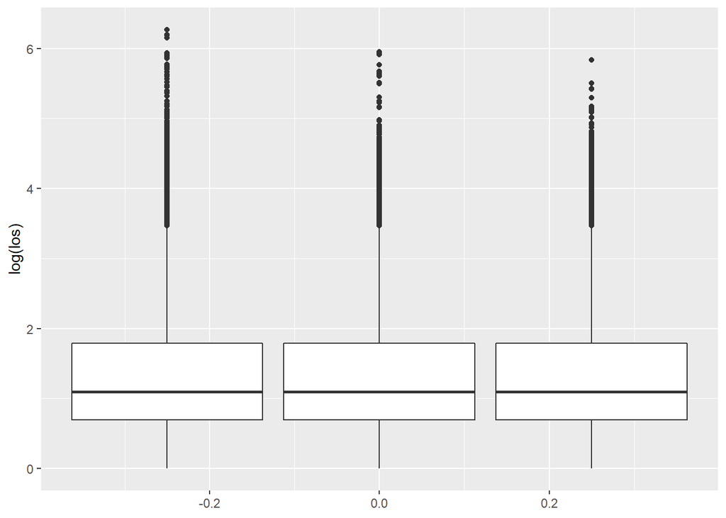

```r
#length of stay seems to be becoming less variable from 2016 to 2018, less upper outliers
DATA2 %>%
  ggplot(aes(group = yoa, y = log(los))) +
  geom_boxplot()
```

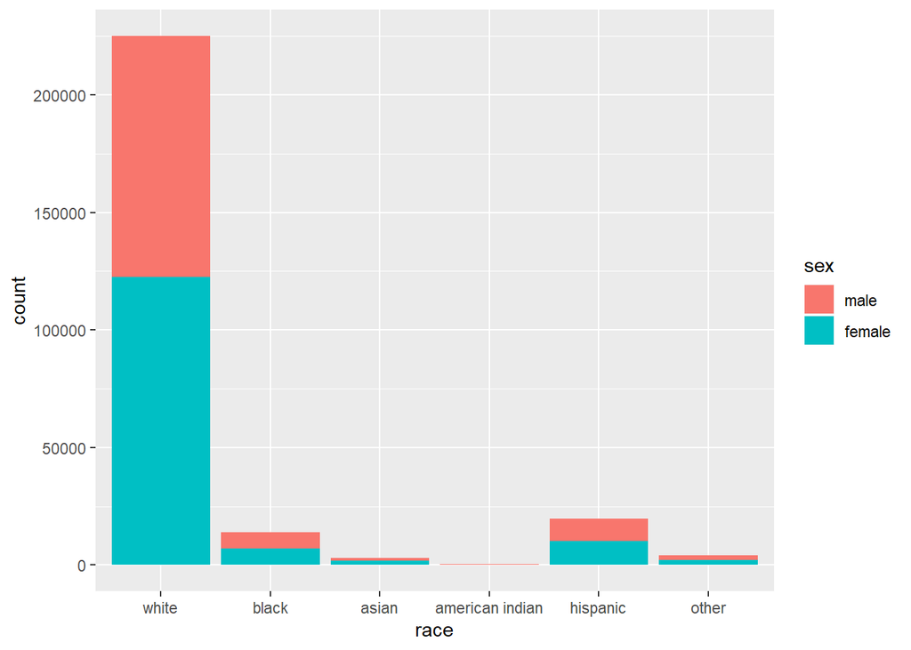

```r
#overwhelming majority white, next is hispanic, about even male/female for each except for american indian
DATA2 %>%
  ggplot(aes(race, fill = sex)) +
  geom_bar() +
  scale_fill_discrete(labels = c("male", "female")) +
  scale_x_discrete(breaks = c("1", "2", "3", "4", "5", "6"),
                   labels = c("white", "black", "asian", "american indian", "hispanic", "other"))
```

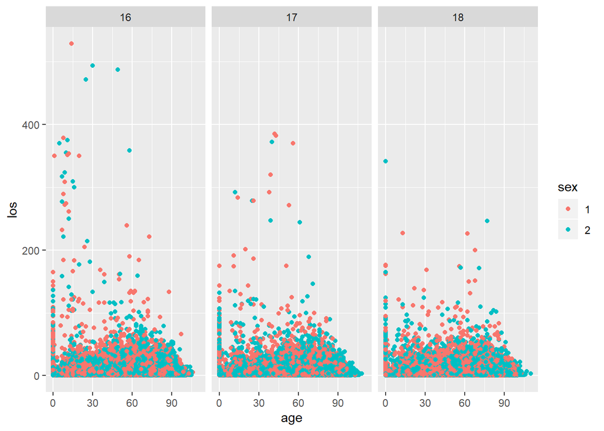

```r
#length of stay is generally more variable for patients who are younger, again less variable in 2018 than 2016
DATA2 %>%
  ggplot(aes(x = age, y = los, color = sex)) +
  geom_point() +
  facet_wrap(DATA2$yoa)
```

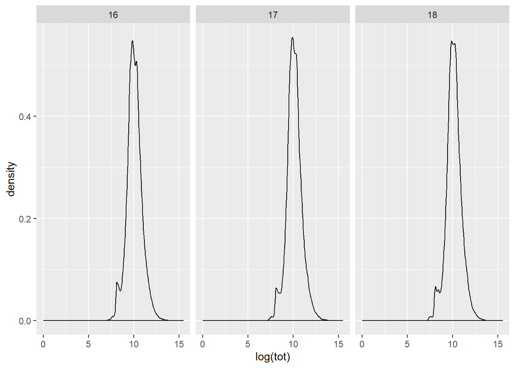

```r
#similar total cost distributions for the three years of admission
DATA2 %>%
  ggplot(aes(log(tot))) +
  geom_density() +
  facet_wrap(DATA2$yoa)
```

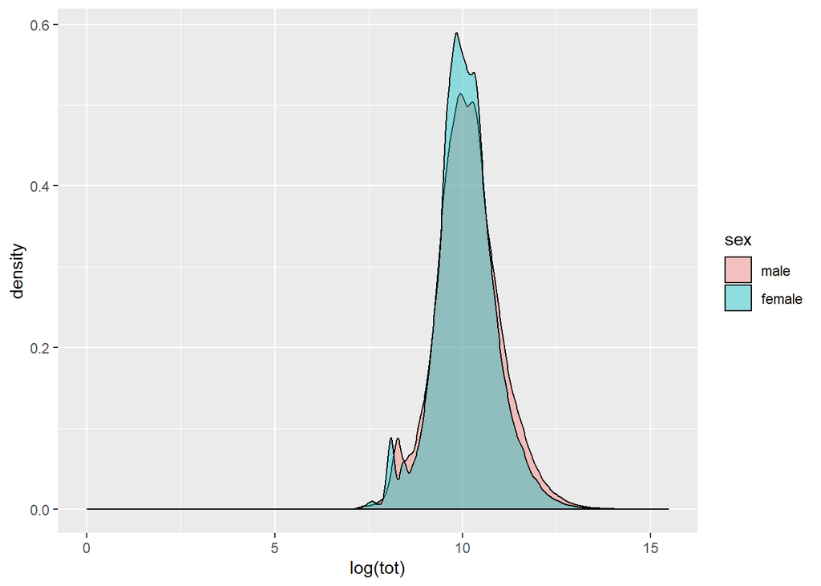

```r
#slightly wider distribution for males, but about the same mean total cost
DATA2 %>%
  ggplot(aes(log(tot), fill = sex)) +
  geom_density(alpha = 0.4) +
  scale_fill_discrete(labels = c("male", "female"))
```

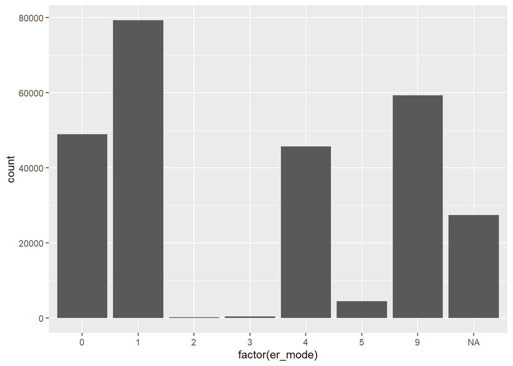

```r
#majority mode of arrivial is rescue service/ambulance followed by information not available
DATA2 %>%
  ggplot(aes(factor(er_mode))) +
  geom_bar()
```

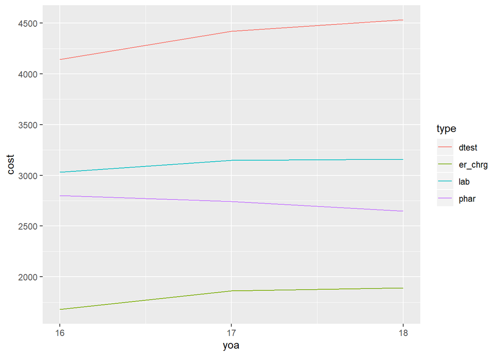

```r
#on average, pharmacy costs decreasing, diagnostic tests increasing by most
DATA2 %>%
  group_by(yoa) %>%
  summarise_at(vars(phar, lab, dtest, er_chrg), mean) %>%
  gather(-yoa, key = "type", value = "cost") %>%
  ggplot(aes(yoa, cost, color = type)) +
  geom_line() +
  scale_x_continuous(breaks = c(16, 17, 18))
```

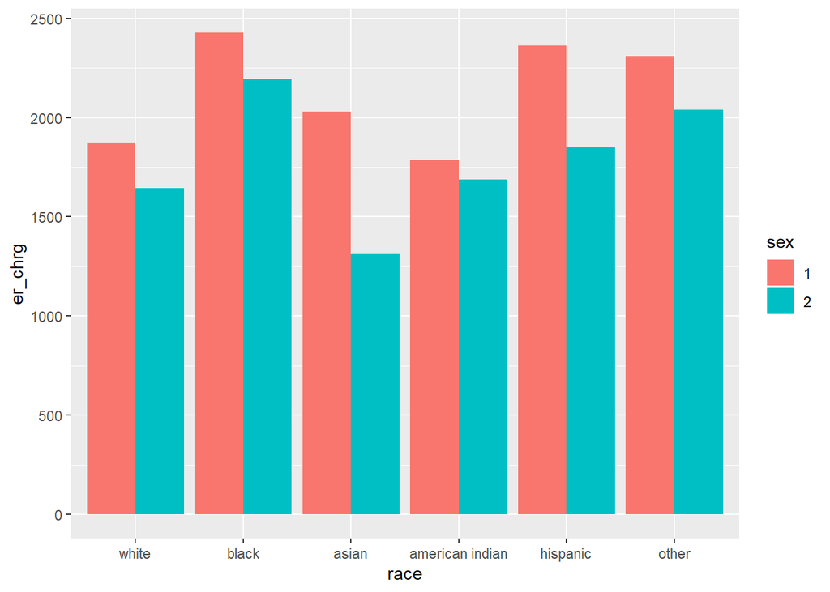

```r
#higher average er charges for males than for females across all races, highest being black males
DATA2 %>%
  ggplot(aes(race, er_chrg, fill = sex)) +
  stat_summary(fun.y = mean, geom = "bar", position = "dodge") +
  scale_x_discrete(labels = c("white", "black", "asian", "american indian", "hispanic", "other"))
```

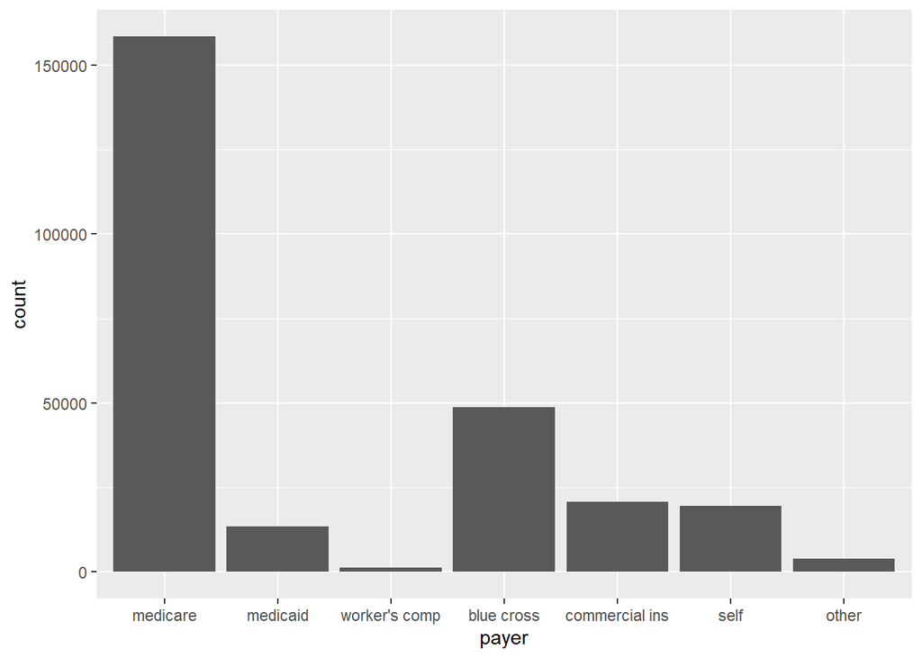

```r
#majority paying with medicare
DATA2 %>%
  ggplot(aes(payer)) +
  geom_bar() +
  scale_x_discrete(labels = c("medicare", "medicaid", "worker's comp",
                              "blue cross", "commercial ins", "self", "other"))
```

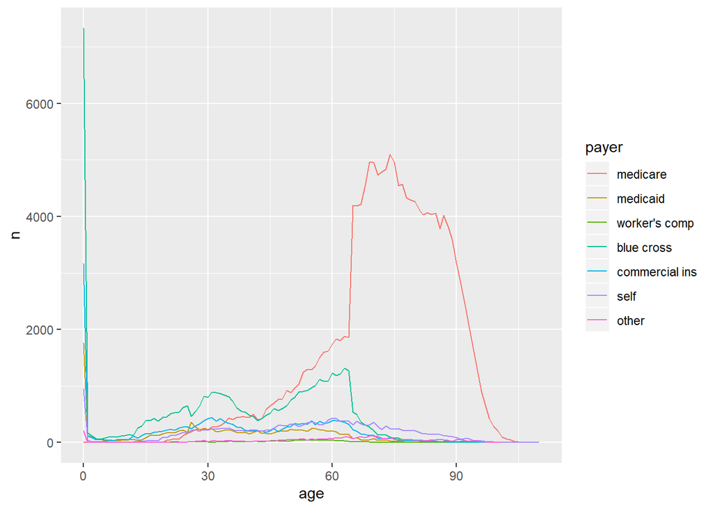

```r
#substantial jump in using medicare around age 65, switch from blue cross to medicare at this age
DATA2 %>%
  group_by(age, payer) %>%
  tally() %>%
  ggplot(aes(age, n, color = payer)) +
  geom_line()+
  scale_color_discrete(labels = c("medicare", "medicaid", "worker's comp",
                              "blue cross", "commercial ins", "self", "other"))
```

The following chunk creates training data and testing data and selects variables that will be used for modeling. These are variables that would be know initially when the patient comes in. For example, none of the total charge variables should be included as they would not be known until the end of the patient’s stay.

```r
DATA3 <- DATA2 %>%
  group_by(dx1) %>%
  mutate(freq_dx1 = n()) %>%
  ungroup() %>%
  group_by(dx2) %>%
  mutate(freq_dx2 = n()) %>%
  ungroup() %>%
  mutate(los_ind = factor(ifelse(los >= 4, 1, 0)),
         quant_dx1 = ntile(freq_dx1, 4),
         quant_dx2 = ntile(freq_dx2, 4)) %>%
  mutate_at(vars(asource, dx1, dx2), as.character) %>%
  select(los_ind, age, pay_ub92, sex, raceethn, provider, moa,
         admtype, service, quant_dx1, quant_dx2, yoa, payer) %>%
  na.omit() %>%
  sample_n(10000)

set.seed(2020)

split <- createDataPartition(DATA3$los_ind, p = 0.7, list = F)
training <- DATA3[split,]
testing <- DATA3[-split,]
```

Decision Tree

```r
mod1 <- train(los_ind ~ ., data = training, method = "rpart2",
              tuneGrid = expand.grid(maxdepth = c(3, 7, 12)),
              trControl = trainControl(method = "cv", number = 10))

mod1.pred <- predict(mod1, testing)
mod1.cm <- confusionMatrix(mod1.pred, testing$los_ind, positive = "1")
mod1.cm
```

```
## Confusion Matrix and Statistics
##
##           Reference
## Prediction    0    1
##          0 1654 1256
##          1   21   68
##
##                Accuracy : 0.5742
##                  95% CI : (0.5563, 0.592)
##     No Information Rate : 0.5585
##     P-Value [Acc > NIR] : 0.0435
##
##                   Kappa : 0.043
##
##  Mcnemar's Test P-Value : <2e-16
##
##             Sensitivity : 0.05136
##             Specificity : 0.98746
##          Pos Pred Value : 0.76404
##          Neg Pred Value : 0.56838
##              Prevalence : 0.44148
##          Detection Rate : 0.02267
##    Detection Prevalence : 0.02968
##       Balanced Accuracy : 0.51941
##
##        'Positive' Class : 1
##
```

```r
mod1
```

```
## CART
##
## 7001 samples
##   12 predictor
##    2 classes: '0', '1'
##
## No pre-processing
## Resampling: Cross-Validated (10 fold)
## Summary of sample sizes: 6300, 6302, 6300, 6301, 6301, 6301, ...
## Resampling results across tuning parameters:
##
##   maxdepth  Accuracy   Kappa
##    3        0.5840577  0.0865451
##    7        0.5829153  0.1004148
##   12        0.5829153  0.1004148
##
## Accuracy was used to select the optimal model using the largest value.
## The final value used for the model was maxdepth = 3.
```

Random Forest with Cross Validation (7-fold, 3 repeats)

```r
mod2 <- train(los_ind ~ ., data = training, method = "ranger",
              num.trees = 100,
              tuneGrid = expand.grid(mtry = c(5, 7, 10), splitrule = "gini",
                                     min.node.size = c(50, 100, 150)),
              trControl = trainControl(method = "repeatedcv", number = 7, repeats = 3))

mod2.pred <- predict(mod2, testing)
mod2.cm <- confusionMatrix(mod2.pred, testing$los_ind, positive = "1")
mod2.cm
```

```
## Confusion Matrix and Statistics
##
##           Reference
## Prediction    0    1
##          0 1314  806
##          1  361  518
##
##                Accuracy : 0.6109
##                  95% CI : (0.5932, 0.6284)
##     No Information Rate : 0.5585
##     P-Value [Acc > NIR] : 3.655e-09
##
##                   Kappa : 0.1821
##
##  Mcnemar's Test P-Value : < 2.2e-16
##
##             Sensitivity : 0.3912
##             Specificity : 0.7845
##          Pos Pred Value : 0.5893
##          Neg Pred Value : 0.6198
##              Prevalence : 0.4415
##          Detection Rate : 0.1727
##    Detection Prevalence : 0.2931
##       Balanced Accuracy : 0.5879
##
##        'Positive' Class : 1
##
```

```r
mod2
```

```
## Random Forest
##
## 7001 samples
##   12 predictor
##    2 classes: '0', '1'
##
## No pre-processing
## Resampling: Cross-Validated (7 fold, repeated 3 times)
## Summary of sample sizes: 6000, 6002, 6000, 6001, 6000, 6001, ...
## Resampling results across tuning parameters:
##
##   mtry  min.node.size  Accuracy   Kappa
##    5     50            0.6028216  0.1741863
##    5    100            0.6075837  0.1821786
##    5    150            0.6087247  0.1827289
##    7     50            0.6031073  0.1781185
##    7    100            0.6047256  0.1781781
##    7    150            0.6059162  0.1792083
##   10     50            0.6006283  0.1741964
##   10    100            0.6031065  0.1765004
##   10    150            0.6052483  0.1792168
##
## Tuning parameter 'splitrule' was held constant at a value of gini
## Accuracy was used to select the optimal model using the largest value.
## The final values used for the model were mtry = 5, splitrule = gini
##  and min.node.size = 150.
```

KNN

```r
mod3 <- train(los_ind ~ ., data = training, method = "knn",
              trControl = trainControl(method = "repeatedcv", number = 5, repeats = 3),
              tuneGrid = expand.grid(k = c(100, 200, 450)))

mod3.pred <- predict(mod3, testing)
mod3.cm <- confusionMatrix(mod3.pred, testing$los_ind, positive = "1")
mod3.cm
```

```
## Confusion Matrix and Statistics
##
##           Reference
## Prediction    0    1
##          0 1197  855
##          1  478  469
##
##                Accuracy : 0.5555
##                  95% CI : (0.5375, 0.5734)
##     No Information Rate : 0.5585
##     P-Value [Acc > NIR] : 0.6368
##
##                   Kappa : 0.071
##
##  Mcnemar's Test P-Value : <2e-16
##
##             Sensitivity : 0.3542
##             Specificity : 0.7146
##          Pos Pred Value : 0.4952
##          Neg Pred Value : 0.5833
##              Prevalence : 0.4415
##          Detection Rate : 0.1564
##    Detection Prevalence : 0.3158
##       Balanced Accuracy : 0.5344
##
##        'Positive' Class : 1
##
```

GLM

```r
mod4 <- glm(los_ind ~ ., training, family = binomial())

mod4.pred <- predict.glm(mod4, testing, type = "response")
mod4.pred.class <- ifelse(mod4.pred > 0.42, 1, 0) %>% factor()

confusionMatrix(mod4.pred.class, testing$los_ind, positive = "1")
```

```
## Confusion Matrix and Statistics
##
##           Reference
## Prediction   0   1
##          0 724 380
##          1 951 944
##
##                Accuracy : 0.5562
##                  95% CI : (0.5382, 0.5741)
##     No Information Rate : 0.5585
##     P-Value [Acc > NIR] : 0.6089
##
##                   Kappa : 0.139
##
##  Mcnemar's Test P-Value : <2e-16
##
##             Sensitivity : 0.7130
##             Specificity : 0.4322
##          Pos Pred Value : 0.4982
##          Neg Pred Value : 0.6558
##              Prevalence : 0.4415
##          Detection Rate : 0.3148
##    Detection Prevalence : 0.6319
##       Balanced Accuracy : 0.5726
##
##        'Positive' Class : 1
##
```

GBM

```r
library(gbm)
mod5 <- train(los_ind ~ ., training, method = "gbm",
              tuneGrid = expand.grid(n.trees = 100,
                                     interaction.depth = c(3, 6),
                                     shrinkage = 0.1,
                                     n.minobsinnode = c(50, 75)))
mod5
```

```
## Stochastic Gradient Boosting
##
## 7001 samples
##   12 predictor
##    2 classes: '0', '1'
##
## No pre-processing
## Resampling: Bootstrapped (25 reps)
## Summary of sample sizes: 7001, 7001, 7001, 7001, 7001, 7001, ...
## Resampling results across tuning parameters:
##
##   interaction.depth  n.minobsinnode  Accuracy   Kappa
##   3                  50              0.6031005  0.1763171
##   3                  75              0.6026811  0.1755932
##   6                  50              0.6047947  0.1828807
##   6                  75              0.6059034  0.1848483
##
## Tuning parameter 'n.trees' was held constant at a value of 100
##
## Tuning parameter 'shrinkage' was held constant at a value of 0.1
## Accuracy was used to select the optimal model using the largest value.
## The final values used for the model were n.trees = 100,
##  interaction.depth = 6, shrinkage = 0.1 and n.minobsinnode = 75.
```

```r
mod5.pred <- predict(mod5, testing)
mod5.cm <- confusionMatrix(mod5.pred, testing$los_ind, positive = "1")
mod5.cm
```

```
## Confusion Matrix and Statistics
##
##           Reference
## Prediction    0    1
##          0 1219  747
##          1  456  577
##
##                Accuracy : 0.5989
##                  95% CI : (0.5811, 0.6165)
##     No Information Rate : 0.5585
##     P-Value [Acc > NIR] : 4.353e-06
##
##                   Kappa : 0.1674
##
##  Mcnemar's Test P-Value : < 2.2e-16
##
##             Sensitivity : 0.4358
##             Specificity : 0.7278
##          Pos Pred Value : 0.5586
##          Neg Pred Value : 0.6200
##              Prevalence : 0.4415
##          Detection Rate : 0.1924
##    Detection Prevalence : 0.3444
##       Balanced Accuracy : 0.5818
##
##        'Positive' Class : 1
##
```

```r
?train
```

```
## starting httpd help server ...
```

```
##  done
```